# 12 Linear regression with grouped data

**TipLearning outcomes**

**Questions**

- How do I perform a linear regression on grouped data?

**Objectives**

- Be able to perform a linear regression on grouped data in R
- Calculate the linear regression for individual groups and visualise these with the data
- Understand and be able to create equations of the regression line
- Be able to deal with interactions in this context

## 12.1 Libraries and functions

**NoteClick to expand**

**R**

### 12.1.1 Libraries

```r
# A collection of R packages designed for data science
library(tidyverse)

# Converts stats functions to a tidyverse-friendly format
library(rstatix)

# Creates diagnostic plots using ggplot2
library(ggResidpanel)

# Helper functions for tidying data
library(broom)
```

### 12.1.2 Functions

```r
# Gets underlying data out of model object
broom::augment()

# Creates diagnostic plots
ggResidpanel::resid_panel()

# Performs an analysis of variance
stats::anova()

# Creates a linear model
stats::lm()
```

**Python**

### 12.1.3 Libraries

```python
# A fundamental package for scientific computing in Python
import numpy as np

# A Python data analysis and manipulation tool
import pandas as pd

# Simple yet exhaustive stats functions.
import pingouin as pg

# Python equivalent of `ggplot2`
from plotnine import *

# Statistical models, conducting tests and statistical data exploration
import statsmodels.api as sm

# Convenience interface for specifying models using formula strings and DataFrames
import statsmodels.formula.api as smf

# Custom Python script for diagnostic plots, load from base working directory
from dgplots import dgplots
```

### 12.1.4 Functions

```python
# Computes natural logarithm of value
numpy.log()

# Plots the first few rows of a DataFrame
pandas.DataFrame.head()

# Reads in a .csv file
pandas.DataFrame.read_csv()

# Creates a model from a formula and data frame
statsmodels.formula.api.ols()

# Custom function to create diagnostic plots
dgplots()
```

Note: you can download the `dgplots` script here.

## 12.2 Purpose and aim

A linear regression analysis with grouped data is used when we have one categorical predictor variable (or factor), and one continuous predictor variable. The response variable must still be continuous however.

For example in an experiment that looks at light intensity in woodland, how is light intensity (continuous: lux) affected by the height at which the measurement is taken, recorded as depth measured from the top of the canopy (continuous: meters) and by the type of woodland (categorical: Conifer or Broad leaf).

[figure not shown]

When analysing these type of data we want to know:

1. Is there a difference between the groups?
2. Does the continuous predictor variable affect the continuous response variable (does canopy depth affect measured light intensity?)
3. Is there any interaction between the two predictor variables? Here an interaction would display itself as a difference in the slopes of the regression lines for each group, so for example perhaps the conifer data set has a significantly steeper line than the broad leaf woodland data set.

In this case, no interaction means that the regression lines will have the same slope. Essentially the analysis is identical to two-way ANOVA.

1. We will plot the data and visually inspect it.
2. We will test for an interaction and if it doesn’t exist then:
   1. We can test to see if either predictor variable has an effect (i.e. do the regression lines have different intercepts? and is the common gradient significantly different from zero?)

We will first consider how to visualise the data before then carrying out an appropriate statistical test.

## 12.3 Data and hypotheses

The data are stored in `data/CS4-treelight.csv`. This is a data frame with four variables; `id`, `light`, `depth` and `species`. `light` is the continuous response variable, `depth` is the continuous predictor variable and `species` is the categorical predictor variable.

Read in the data and inspect them:

**R**

```r
# read in the data
treelight <- read_csv("data/CS4-treelight.csv")

# inspect the data
treelight
```

```
# A tibble: 23 × 4
      id light depth species
   <dbl> <dbl> <dbl> <chr>
 1     1 4106.  1    Conifer
 2     2 4934.  1.75 Conifer
 3     3 4417.  2.5  Conifer
 4     4 4529.  3.25 Conifer
 5     5 3443.  4    Conifer
 6     6 4640.  4.75 Conifer
 7     7 3082.  5.5  Conifer
 8     8 2368.  6.25 Conifer
 9     9 2777.  7    Conifer
10    10 2419.  7.75 Conifer
# ℹ 13 more rows
```

**Python**

```python
# load the data
treelight_py = pd.read_csv("data/CS4-treelight.csv")

# and have a look
treelight_py.head()
```

```
   id        light  depth  species
0   1  4105.646110   1.00  Conifer
1   2  4933.925144   1.75  Conifer
2   3  4416.527443   2.50  Conifer
3   4  4528.618186   3.25  Conifer
4   5  3442.610306   4.00  Conifer
```

## 12.4 Summarise and visualise

**R**

```r
# plot the data
ggplot(treelight,
       aes(x = depth, y = light, colour = species)) +
  geom_point() +
  scale_color_brewer(palette = "Dark2") +
  labs(x = "Depth (m)",
       y = "Light intensity (lux)")
```

[figure not shown]

**Python**

```python
# plot the data
p = (ggplot(treelight_py,
        aes(x = "depth",
            y = "light",
            colour = "species")) +
     geom_point() +
     scale_color_brewer(type = "qual", palette = "Dark2") +
     labs(x = "Depth (m)",
         y = "Light intensity (lux)"))

p.show()
```

[figure not shown]

It looks like there is a slight negative correlation between depth and light intensity, with light intensity reducing as the canopy depth increases. It would be useful to plot the regression lines in this plot.

**R**

```r
# plot the data
ggplot(treelight,
       aes(x = depth, y = light, colour = species)) +
  geom_point() +
  # add regression lines
  geom_smooth(method = "lm", se = FALSE) +
  scale_color_brewer(palette = "Dark2") +
  labs(x = "Depth (m)",
       y = "Light intensity (lux)")
```

[figure not shown]

**Python**

```python
# plot the data
p = (ggplot(treelight_py,
        aes(x = "depth",
            y = "light",
            colour = "species")) +
     geom_point() +
     # add regression lines
     geom_smooth(method = "lm", se = False) +
     scale_color_brewer(type = "qual", palette = "Dark2") +
     labs(x = "Depth (m)",
          y = "Light intensity (lux)"))

p.show()
```

[figure not shown]

Looking at this plot, there doesn’t appear to be any significant interaction between the woodland type (`Broadleaf` and `Conifer`) and the depth at which light measurements were taken (`depth`) on the amount of light intensity getting through the canopy as the gradients of the two lines appear to be very similar. There does appear to be a noticeable slope to both lines and both lines look as though they have very different intercepts. All of this suggests that there isn’t any interaction but that both `depth` and `species` have a significant effect on `light` independently.

## 12.5 Implement and interpret the test

In this case we’re going to implement the test before checking the assumptions (I know, let’s live a little!). You’ll find out why soon…

We can test for a possible interaction more formally:

**R**

```r
anova(lm(light ~ depth * species,
         data = treelight))
```

```
Analysis of Variance Table

Response: light
              Df   Sum Sq  Mean Sq  F value    Pr(>F)
depth          1 30812910 30812910 107.8154 2.861e-09 ***
species        1 51029543 51029543 178.5541 4.128e-11 ***
depth:species  1   218138   218138   0.7633    0.3932
Residuals     19  5430069   285793
---
Signif. codes:  0 '***' 0.001 '**' 0.01 '*' 0.05 '.' 0.1 ' ' 1
```

Remember that `depth * species` is a shorthand way of writing the full set of `depth + species + depth:species` terms in R *i.e.* both main effects and the interaction effect.

**Python**

Unfortunately there is no clear way of defining interaction models in pingouin. So we’re resorting back to `statsmodels`, just like we had to when we performed the Shapiro-Wilk test on the residuals.

If you haven’t loaded `statsmodels` yet, run the following:

```python
import statsmodels.api as sm
import statsmodels.formula.api as smf
```

Next, we create a linear model and get the `.fit()`:

```python
# create a linear model
model = smf.ols(formula = "light ~ depth * C(species)",
                data = treelight_py)

# and get the fitted parameters of the model
lm_treelight_py = model.fit()
```

To get the relevant values, we can print the summary of the model fit. This gives us a rather huge table. Don’t be too daunted by it - there is a logic to the madness and for now we’re mainly interested in the `P>|t|` column.

```python
print(lm_treelight_py.summary())
```

```
                            OLS Regression Results
==============================================================================
Dep. Variable:                  light   R-squared:                       0.938
Model:                            OLS   Adj. R-squared:                  0.928
Method:                 Least Squares   F-statistic:                     95.71
Date:                Wed, 03 Dec 2025   Prob (F-statistic):           1.19e-11
Time:                        14:05:16   Log-Likelihood:                -174.91
No. Observations:                  23   AIC:                             357.8
Df Residuals:                      19   BIC:                             362.4
Df Model:                           3
Covariance Type:            nonrobust
===============================================================================================
                                  coef    std err          t      P>|t|      [0.025      0.975]
-----------------------------------------------------------------------------------------------
Intercept                    7798.5655    298.623     26.115      0.000    7173.541    8423.590
C(species)[T.Conifer]       -2784.5833    442.274     -6.296      0.000   -3710.274   -1858.893
depth                        -221.1256     61.802     -3.578      0.002    -350.478     -91.773
depth:C(species)[T.Conifer]   -71.0357     81.309     -0.874      0.393    -241.217      99.145
==============================================================================
Omnibus:                        1.435   Durbin-Watson:                   2.176
Prob(Omnibus):                  0.488   Jarque-Bera (JB):                1.269
Skew:                           0.444   Prob(JB):                        0.530
Kurtosis:                       2.267   Cond. No.                         31.8
==============================================================================

Notes:
[1] Standard Errors assume that the covariance matrix of the errors is correctly specified.
```

As with two-way ANOVA we have a row in the table for each of the different effects. At this point we are particularly interested in the p-values. We need to look at the interaction first.

The interaction term between `depth` and `species` has a p-value of 0.393 (which is bigger than 0.05) and so we can conclude that the interaction between `depth` and `species` isn’t significant. As such we can now consider whether each of the predictor variables independently has an effect.

Both `depth` and `species` have very small p-values (2.86x10<sup>-9</sup> and 4.13x10 <sup>-11</sup>) and so we can conclude that they do have a significant effect on `light`.

This means that the two regression lines should have the same non-zero slope, but different intercepts. We would now like to know what those values are.

### 12.5.1 Finding intercept values

Finding the intercept values is not entirely straightforward and there is some deciphering required to get this right.

For a simple straight line such as the linear regression for the conifer data by itself, the output is relatively straightforward:

**R**

I’m being a bit lazy here. Since I don’t want to save the filtered data in a separate object, I’m using the pipe to send the Conifer data to the `lm()` function. However, the first argument in the `lm()` function is *not* data, so we need to tell it specifically that the data is coming from the pipe. We do this with the `.` notation:

```r
# filter the Conifer data and fit a linear model
treelight %>%
  filter(species == "Conifer") %>%
  lm(light ~ depth, data = .)
```

```
Call:
lm(formula = light ~ depth, data = .)

Coefficients:
(Intercept)        depth
     5014.0       -292.2
```

**Python**

We have two options to obtain the intercept for conifers only. We could subset our data, keeping only the conifer values. We could then create a linear model of those data, and obtain the relevant intercept.

However, since we already created a model for the entire data set (including the interaction term) and printed the summary of that, we can actually derive the intercept value with the information that we’ve got.

In the `coef` table of the summary there are several values:

```
Intercept                      7798.5655
C(species)[T.Conifer]         -2784.5833
depth                         -221.1256
depth:C(species)[T.Conifer]   -71.0357
```

This tells us that the *overall* intercept value for the model with the interaction term is 7798.5655. The `C(species)[T.Conifer]` term means that, to go from this overall intercept value *to the intercept for conifer*, we need to add -2784.5833.

Doing the maths gives us an intercept of $7798.5655 + (-2784.5833) = 5014$ if we round this.

Equally, if we want to get the coefficient for `depth`, then we take the reference value of -221.1256 and add the value next to `depth:C(species)[T.Conifer]` to it. This gives us $-221.1256 + (-71.0357) = -292.2$ if we round it.

We can interpret this as meaning that the intercept of the regression line is 5014 and the coefficient of the depth variable (the number in front of it in the equation) is -292.2.

So, the equation of the regression line for the conifer data is given by:

$$\begin{equation}
light = 5014 + -292.2 \times depth
\end{equation}$$

This means that for every extra 1 m of depth of forest canopy we lose 292.2 lux of light.

When we looked at the full data set, we found that interaction wasn’t important. This means that we will have a model with two distinct intercepts but only a single slope (that’s what you get for a linear regression without any interaction), so we need to calculate that specific combination. We do this is as follows:

**R**

```r
lm(light ~ depth + species,
   data = treelight)
```

```
Call:
lm(formula = light ~ depth + species, data = treelight)

Coefficients:
   (Intercept)           depth  speciesConifer
        7962.0          -262.2         -3113.0
```

Notice the `+` symbol in the argument, as opposed to the `*` symbol used earlier. This means that we are explicitly *not* including an interaction term in this fit, and consequently we are forcing R to calculate the equation of lines which have the same gradient.

Ideally we would like R to give us two equations, one for each forest type, so four parameters in total. Unfortunately, R is parsimonious and doesn’t do that. Instead R gives you three coefficients, and these require a bit of interpretation.

The first two numbers that R returns (underneath `Intercept` and `depth`) are the exact intercept and slope coefficients for one of the lines (in this case they correspond to the data for `Broadleaf` woodlands).

For the coefficients belonging to the other line, R uses these first two coefficients as baseline values and expresses the other coefficients relative to these ones. R also doesn’t tell you explicitly which group it is using as its baseline reference group! (Did I mention that R can be very helpful at times 😉?)

So, how to decipher the above output?

First, I need to work out which group has been used as the baseline.

- It will be the group that comes first alphabetically, so it should be `Broadleaf`
- The other way to check would be to look and see which group is not mentioned in the above table. `Conifer` is mentioned (in the `SpeciesConifer` heading) and so again the baseline group is `Broadleaf.`

This means that the intercept value and `depth` coefficient correspond to the `Broadleaf` group and as a result I know what the equation of one of my lines is:

Broadleaf:

$$\begin{equation}
light = 7962 + -262.2 \times depth
\end{equation}$$

In this example we know that the gradient is the same for both lines (because we explicitly asked to exclude an interaction), so all I need to do is find the intercept value for the `Conifer` group. Unfortunately, the final value given underneath `SpeciesConifer` does not give me the intercept for `Conifer`, instead it tells me the difference between the `Conifer` group intercept and the baseline intercept i.e. the equation for the regression line for conifer woodland is given by:

$$\begin{equation}
light = (7962 + -3113) + -262.2 \times depth
\end{equation}$$

**Python**

The way we obtain the values for the model without the interaction is very similar to what we did for the conifer data. We need to update our model first, to remove the interaction:

```python
# create a linear model
model = smf.ols(formula = "light ~ depth + C(species)",
                data = treelight_py)

# and get the fitted parameters of the model
lm_treelight_add_py = model.fit()
```

Notice the `+` symbol in the argument, as opposed to the `*` symbol used earlier. This means that we are explicitly *not* including an interaction term in this fit, and consequently we are forcing Python to calculate the equation of lines which have the same gradient.

We can get the relevant coefficients as follows:

```python
print(lm_treelight_add_py.summary())
```

```
                            OLS Regression Results
==============================================================================
Dep. Variable:                  light   R-squared:                       0.935
Model:                            OLS   Adj. R-squared:                  0.929
Method:                 Least Squares   F-statistic:                     144.9
Date:                Wed, 03 Dec 2025   Prob (F-statistic):           1.26e-12
Time:                        14:05:16   Log-Likelihood:                -175.37
No. Observations:                  23   AIC:                             356.7
Df Residuals:                      20   BIC:                             360.1
Df Model:                           2
Covariance Type:            nonrobust
=========================================================================================
                            coef    std err          t      P>|t|      [0.025      0.975]
-----------------------------------------------------------------------------------------
Intercept              7962.0316    231.356     34.415      0.000    7479.431    8444.633
C(species)[T.Conifer] -3113.0265    231.586    -13.442      0.000   -3596.106   -2629.947
depth                  -262.1656     39.922     -6.567      0.000    -345.441    -178.891
==============================================================================
Omnibus:                        2.068   Durbin-Watson:                   2.272
Prob(Omnibus):                  0.356   Jarque-Bera (JB):                1.677
Skew:                           0.633   Prob(JB):                        0.432
Kurtosis:                       2.618   Cond. No.                         13.9
==============================================================================

Notes:
[1] Standard Errors assume that the covariance matrix of the errors is correctly specified.
```

Again, I need to work out which group has been used as the baseline.

- It will be the group that comes first alphabetically, so it should be `Broadleaf`
- The other way to check would be to look and see which group is not mentioned in the above table. `Conifer` is mentioned (in the `C(species)[T.Conifer]` heading) and so again the baseline group is `Broadleaf.`

This means that the intercept value and `depth` coefficient correspond to the `Broadleaf` group and as a result I know what the equation of one of my lines is:

Broadleaf:

$$\begin{equation}
light = 7962 + -262.2 \times depth
\end{equation}$$

In this example we know that the gradient is the same for both lines (because we explicitly asked to exclude an interaction), so all I need to do is find the intercept value for the `Conifer` group. Unfortunately, the final value given in `C(species)[T.Conifer]` does not give me the intercept for `Conifer`, instead it tells me the difference between the `Conifer` group intercept and the baseline intercept i.e. the equation for the regression line for conifer woodland is given by:

$$\begin{equation}
light = (7962 + -3113) + -262.2 \times depth
\end{equation}$$

### 12.5.2 Adding custom regression lines

In the example above we determined that the interaction term `species:depth` was not significant. It would be good to visualise the model without the interaction term.

**R**

This is relatively straightforward if we understand the output of the model a bit better.

First of all, we load the `broom` library. This is part of tidyverse, so you don’t have to install it. It is not loaded by default, hence us loading it. What broom does it changes the format of many common base R outputs into a more tidy format, so we can work with the output in our analyses more easily.

The function we use here is called `augment()`. What this does is take a model object and a dataset and adds information about each observation in the dataset.

```r
# define the model without interaction term
lm_additive <- lm(light ~ species + depth,
                  data = treelight)

# load the broom package
library(broom)

# augment the model
lm_additive %>% augment()
```

```
# A tibble: 23 × 9
   light species depth .fitted .resid   .hat .sigma .cooksd .std.resid
   <dbl> <chr>   <dbl>   <dbl>  <dbl>  <dbl>  <dbl>   <dbl>      <dbl>
 1 4106. Conifer  1      4587.  -481. 0.191    531. 0.0799      -1.01
 2 4934. Conifer  1.75   4390.   544. 0.156    528. 0.0766       1.11
 3 4417. Conifer  2.5    4194.   223. 0.128    542. 0.00985      0.449
 4 4529. Conifer  3.25   3997.   532. 0.105    530. 0.0440       1.06
 5 3443. Conifer  4      3800.  -358. 0.0896   538. 0.0163      -0.706
 6 4640. Conifer  4.75   3604.  1037. 0.0801   486. 0.120        2.03
 7 3082. Conifer  5.5    3407.  -325. 0.0769   540. 0.0113      -0.637
 8 2368. Conifer  6.25   3210.  -842. 0.0801   507. 0.0793      -1.65
 9 2777. Conifer  7      3014.  -237. 0.0896   542. 0.00719     -0.468
10 2419. Conifer  7.75   2817.  -398. 0.105    537. 0.0247      -0.792
# ℹ 13 more rows
```

The output shows us lots of data. Our original `light` values are in the `light` column and it’s the same for `species` and `depth`. What has been added is information about the fitted (or predicted) values based on the `light ~ depth + species` model we defined.

The fitted or predicted values are in the `.fitted` column, with corresponding residuals in the `.resid` column. Remember, your data = predicted values + error, so if you would add `.fitted` + `resid` then you would end up with your original data again.

Using this information we can now plot the regression lines by `species`:

```r
# plot the regression lines by species
lm_additive %>%
  augment() %>%
  ggplot(aes(x = depth, y = .fitted, colour = species)) +
  geom_line() +
  scale_color_brewer(palette = "Dark2")
```

[figure not shown]

Lastly, if we would want to plot the data and regression lines together, we could change the code as follows:

```r
# plot the regression lines
lm_additive %>%
  augment() %>%
  ggplot(aes(x = depth, y = .fitted, colour = species)) +
  # add the original data points
  geom_point(data = treelight,
             aes(x = depth, y = light, colour = species)) +
  geom_line() +
  scale_color_brewer(palette = "Dark2") +
  labs(x = "Depth (m)",
       y = "Light intensity (lux)")
```

[figure not shown]

**Python**

To do this, we need to do the following:

- create a linear model *without* the interaction term (we did this previously)
- extract the predicted values of the model
- plot these against the original data

```python
# get predicted values
lm_treelight_add_py.predict()
```

```
array([4586.83958789, 4390.21542165, 4193.59125541, 3996.96708918,
       3800.34292294, 3603.7187567 , 3407.09459046, 3210.47042422,
       3013.84625799, 2817.22209175, 2620.59792551, 2423.97375927,
       2227.34959303, 7322.87199901, 7047.59816627, 5781.86286681,
       7543.35323075, 6319.56442008, 7267.03073579, 7773.27242247,
       5822.76069339, 7766.98044915, 6532.70501628])
```

We can’t easily use the predicted values in this kind of format, so we’re adding them to the existing data, in a column called `.fitted`:

```python
# add predicted values to data set
treelight_py['.fitted'] = lm_treelight_add_py.predict()

# have a peek at the data
treelight_py.head()
```

```
   id        light  depth  species      .fitted
0   1  4105.646110   1.00  Conifer  4586.839588
1   2  4933.925144   1.75  Conifer  4390.215422
2   3  4416.527443   2.50  Conifer  4193.591255
3   4  4528.618186   3.25  Conifer  3996.967089
4   5  3442.610306   4.00  Conifer  3800.342923
```

Now we can simply plot the data:

```python
# plot the data
p = (ggplot(treelight_py,
        aes(x = "depth",
            y = "light",
            colour = "species")) +
     geom_point() +
     # add regression lines
     geom_line(aes(x = "depth",
                   y = ".fitted",
                   colour = "species")) +
     scale_color_brewer(type = "qual", palette = "Dark2") +
     labs(x = "Depth (m)",
          y = "Light intensity (lux)"))

p.show()
```

[figure not shown]

## 12.6 Assumptions

In this case we first wanted to check if the interaction was significant, prior to checking the assumptions. If we would have checked the assumptions first, then we would have done that one the full model (with the interaction), then done the ANOVA if everything was OK. We would have then found out that the interaction was not significant, meaning we’d have to re-check the assumptions with the new model. In what order you do it is a bit less important here. The main thing is that you check the assumptions and report on it!

Anyway, hopefully you’ve got the gist of checking assumptions for linear models by now: diagnostic plots!

**R**

```r
resid_panel(lm_additive,
            plots = c("resid", "qq", "ls", "cookd"),
            smoother = TRUE)
```

[figure not shown]

**Python**

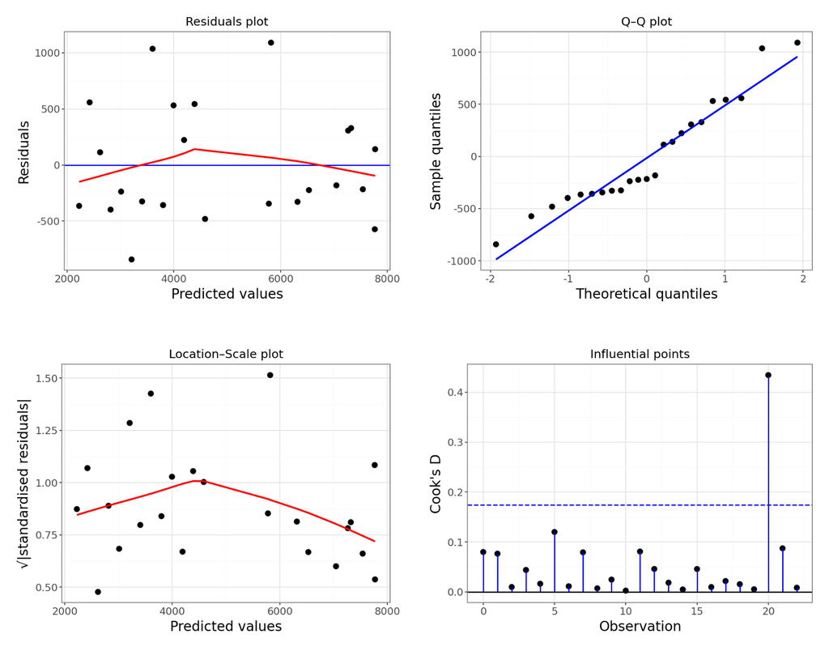

```python
dgplots(lm_treelight_add_py)
```

Woohoo!

## 12.7 Dealing with interaction

If there *had been* a significant interaction between the two predictor variables (for example, if light intensity had dropped off significantly faster in conifer woods than in broad leaf woods, in addition to being lower overall, then we would again be looking for two equations for the linear regression, but this time the gradients vary as well. In this case interaction is important and so we need the output from a linear regression that explicitly includes the interaction term:

**R**

```r
lm(light ~ depth + species + depth:species,
   data = treelight)
```

or written using the short-hand:

```r
lm(light ~ depth * species,
   data = treelight)
```

There really is absolutely no difference in the end result. Either way this gives us the following output:

```
Call:
lm(formula = light ~ depth * species, data = treelight)

Coefficients:
         (Intercept)                 depth        speciesConifer
             7798.57               -221.13              -2784.58
depth:speciesConifer
              -71.04
```

As before the Broadleaf line is used as the baseline regression and we can read off the values for its intercept and slope directly:

Broadleaf:
$$\begin{equation}
light = 7798.57 + -221.13 \times depth
\end{equation}$$

Note that this is different from the previous section, by allowing for an interaction all fitted values will change.

For the conifer line we will have a different intercept value and a different gradient value. As before the value underneath `speciesConifer` gives us the difference between the intercept of the conifer line and the broad leaf line. The new, additional term `depth:speciesConifer` tells us how the coefficient of `depth` varies for the conifer line i.e. how the gradient is different. Putting these two together gives us the following equation for the regression line conifer woodland:

Conifer:
$$\begin{equation}
light = (7798.57 + -2784.58) + (-221.13 + -71.04) \times depth
\end{equation}$$

$$\begin{equation}
light = 5014 + -292.2 \times depth
\end{equation}$$

**Python**

We’ve actually created this model before, but for clarity we’ll define it here again.

```python
# create a linear model
model = smf.ols(formula = "light ~ depth * C(species)",
                data = treelight_py)

# and get the fitted parameters of the model
lm_treelight_py = model.fit()
```

We get the model parameters as follows:

```python
print(lm_treelight_py.summary())
```

```
                            OLS Regression Results
==============================================================================
Dep. Variable:                  light   R-squared:                       0.938
Model:                            OLS   Adj. R-squared:                  0.928
Method:                 Least Squares   F-statistic:                     95.71
Date:                Wed, 03 Dec 2025   Prob (F-statistic):           1.19e-11
Time:                        14:05:18   Log-Likelihood:                -174.91
No. Observations:                  23   AIC:                             357.8
Df Residuals:                      19   BIC:                             362.4
Df Model:                           3
Covariance Type:            nonrobust
===============================================================================================
                                  coef    std err          t      P>|t|      [0.025      0.975]
-----------------------------------------------------------------------------------------------
Intercept                    7798.5655    298.623     26.115      0.000    7173.541    8423.590
C(species)[T.Conifer]       -2784.5833    442.274     -6.296      0.000   -3710.274   -1858.893
depth                        -221.1256     61.802     -3.578      0.002    -350.478     -91.773
depth:C(species)[T.Conifer]   -71.0357     81.309     -0.874      0.393    -241.217      99.145
==============================================================================
Omnibus:                        1.435   Durbin-Watson:                   2.176
Prob(Omnibus):                  0.488   Jarque-Bera (JB):                1.269
Skew:                           0.444   Prob(JB):                        0.530
Kurtosis:                       2.267   Cond. No.                         31.8
==============================================================================

Notes:
[1] Standard Errors assume that the covariance matrix of the errors is correctly specified.
```

As before the Broadleaf line is used as the baseline regression and we can read off the values for its intercept and slope directly:

Broadleaf:
$$\begin{equation}
light = 7798.57 + -221.13 \times depth
\end{equation}$$

Note that this is different from the previous section, by allowing for an interaction all fitted values will change.

For the conifer line we will have a different intercept value and a different gradient value. As before the value next to `C(species)[T.Conifer]` gives us the difference between the intercept of the conifer line and the broad leaf line. The interaction term `depth:C(species)[T.Conifer]` tells us how the coefficient of `depth` varies for the conifer line i.e. how the gradient is different. Putting these two together gives us the following equation for the regression line conifer woodland:

Conifer:
$$\begin{equation}
light = (7798.57 + -2784.58) + (-221.13 + -71.04) \times depth
\end{equation}$$

$$\begin{equation}
light = 5014 + -292.2 \times depth
\end{equation}$$

These also happen to be exactly the regression lines that you would get by calculating a linear regression on each group’s data separately.

## 12.8 Exercises

### 12.8.1 Clover and yarrow

**ExerciseExercise 1**

Level:

Clover and yarrow field trials

The `data/CS4-clover.csv` data set contains information on field trials at three different farms (`A`, `B` and `C`). Each farm recorded the yield of clover in each of ten fields along with the density of yarrow stalks in each field.

- Investigate how clover yield is affected by yarrow stalk density. Is there evidence of competition between the two species?
- Is there a difference between farms?

**TipAnswer**

**R**

```r
clover <- read_csv("data/CS4-clover.csv")
```

This data set has three variables; `yield` (which is the response variable), `yarrow` (which is a continuous predictor variable) and `farm` (which is the categorical predictor variables). As always we’ll visualise the data first:

```r
# plot the data
ggplot(clover,
       aes(x = yarrow, y = yield,
           colour = farm)) +
  geom_point() +
  scale_color_brewer(palette = "Dark2")
```

[figure not shown]

Looking at this plot as it stands, it’s pretty clear that yarrow density has a significant effect on yield, but it’s pretty hard to see from the plot whether there is any effect of `farm`, or whether there is any interaction. In order to work that out we’ll want to add the regression lines for each `farm` separately.

```r
# plot the data
ggplot(clover,
       aes(x = yarrow, y = yield,
           colour = farm, group = farm)) +
  geom_point() +
  geom_smooth(method = "lm", se = FALSE) +
  scale_color_brewer(palette = "Dark2")
```

[figure not shown]

The regression lines are very close together. Although the line for `Farm C` crosses the other two, it doesn’t look like we’re going to see a very strong interaction - if there is one. There doesn’t seem to be an effect of `farm` in general, since the lines are not separate from each other.

Let’s carry out the analysis:

```r
lm_clover <- lm(yield ~ yarrow * farm,
                data = clover)

anova(lm_clover)
```

```
Analysis of Variance Table

Response: yield
            Df Sum Sq Mean Sq F value    Pr(>F)
yarrow       1 8538.3  8538.3 28.3143 1.847e-05 ***
farm         2    3.8     1.9  0.0063    0.9937
yarrow:farm  2  374.7   187.4  0.6213    0.5457
Residuals   24 7237.3   301.6
---
Signif. codes:  0 '***' 0.001 '**' 0.01 '*' 0.05 '.' 0.1 ' ' 1
```

This confirms our suspicions from looking at the plot. There isn’t any interaction between `yarrow` and `farm.` `yarrow` density has a statistically significant effect on `yield` but there isn’t any difference between the different farms on the yields of clover.

Let’s check the assumptions:

```r
resid_panel(lm_clover,
            plots = c("resid", "qq", "ls", "cookd"),
            smoother = TRUE)
```

[figure not shown]

This is a borderline case.

**Python**

```python
clover_py = pd.read_csv("data/CS4-clover.csv")
```

This data set has three variables; `yield` (which is the response variable), `yarrow` (which is a continuous predictor variable) and `farm` (which is the categorical predictor variables). As always we’ll visualise the data first:

```python
# plot the data
p = (ggplot(clover_py,
        aes(x = "yarrow",
            y = "yield", colour = "farm")) +
     geom_point() +
     scale_color_brewer(type = "qual", palette = "Dark2"))

p.show()
```

[figure not shown]

Looking at this plot as it stands, it’s pretty clear that yarrow density has a significant effect on yield, but it’s pretty hard to see from the plot whether there is any effect of `farm`, or whether there is any interaction. In order to work that out we’ll want to add the regression lines for each `farm` separately.

```python
# plot the data
p = (ggplot(clover_py,
        aes(x = "yarrow",
            y = "yield", colour = "farm")) +
     geom_point() +
     geom_smooth(method = "lm", se = False) +
     scale_color_brewer(type = "qual", palette = "Dark2"))

p.show()
```

[figure not shown]

The regression lines are very close together. Although the line for `Farm C` crosses the other two, it doesn’t look like we’re going to see a very strong interaction - if there is one. There doesn’t seem to be an effect of `farm` in general, since the lines are not separate from each other.

Let’s carry out the analysis. First, we need to change the name of the `yield` column, because `yield` is a keyword in Python, and we can’t use it inside the model formula. How annoying.

```python
# rename yield column
clover_py = clover_py.rename(columns = {"yield": "clover_yield"})

# create a linear model
model = smf.ols(formula = "clover_yield ~ yarrow * C(farm)",
                data = clover_py)

# and get the fitted parameters of the model
lm_clover_py = model.fit()
```

Perform an ANOVA on the model:

```python
sm.stats.anova_lm(lm_clover_py, typ = 2)
```

```
                     sum_sq    df          F    PR(>F)
C(farm)            3.808918   2.0   0.006315  0.993706
yarrow          8540.833898   1.0  28.322674  0.000018
yarrow:C(farm)   374.718749   2.0   0.621312  0.545659
Residual        7237.311354  24.0        NaN       NaN
```

This confirms our suspicions from looking at the plot. There isn’t any interaction between `yarrow` and `farm.` `yarrow` density has a statistically significant effect on `yield` but there isn’t any difference between the different farms on the yields of clover.

Let’s check the assumptions:

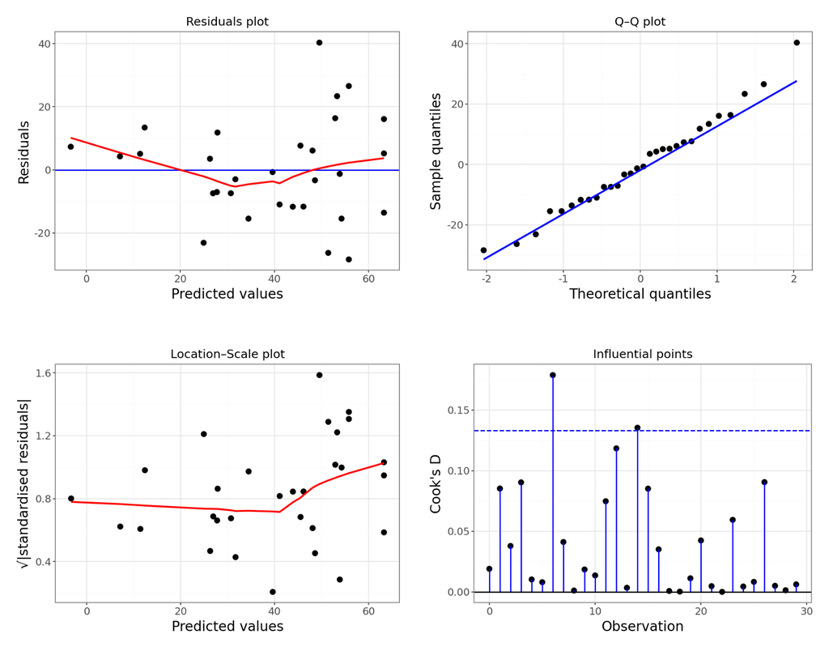

```python
dgplots(lm_clover_py)
```

This is a borderline case.

We have two options; both of which are arguably OK to do in real life.

1. We can claim that these assumptions are well enough met and just report the analysis that we’ve just done.
2. We can decide that the analysis is not appropriate and look for other options.
   1. We can try to transform the data by taking logs of `yield.` This might fix both of our problems: taking logs of the response variable has the effect of improving heterogeneity of variance when the Residuals plot is more spread out on the right vs. the left (like ours). It also is appropriate if we think the true relationship between the response and predictor variables is exponential rather than linear (which we might have). We do have the capabilities to try this option.
   2. We could try a permutation based approach (beyond the remit of this course, and actually a bit tricky in this situation). This wouldn’t address the non-linearity but it would deal with the variance assumption.
   3. We could come up with a specific functional, mechanistic relationship between yarrow density and clover yield based upon other aspects of their biology. For example there might be a threshold effect such that for yarrow densities below a particular value, clover yields are unaffected, but as soon as yarrow values get above that threshold the clover yield decreases (maybe even linearly). This would require a much better understanding of clover-yarrow dynamics (of which I personally know very little).

Let’s do a quick little transformation of the data, and repeat our analysis see if our assumptions are better met this time (just for the hell of it):

**R**

```r
# plot log-transformed data
ggplot(clover,
       aes(x = yarrow, y = log(yield), colour = farm)) +
  geom_point() +
  geom_smooth(method = "lm", se = FALSE) +
  scale_color_brewer(palette = "Dark2")
```

[figure not shown]

**Python**

To log-transform our data, we require `numpy`.

```python
# import numpy
import numpy as np
```

First, we create a new column containing the log-transformed data:

```python
clover_py["log_yield"] = np.log(clover_py["clover_yield"])
```

Then we can plot them:

```python
# plot log-transformed data
p = (ggplot(clover_py,
         aes(x = "yarrow",
             y = "log_yield", colour = "farm")) +
     geom_point() +
     geom_smooth(method = "lm", se = False) +
     scale_color_brewer(type = "qual", palette = "Dark2"))

p.show()
```

[figure not shown]

Again, this looks plausible. There’s a noticeable outlier from Farm B (data point at the bottom of the plot) but otherwise we see that: there probably isn’t an interaction; there is likely to be an effect of `yarrow` on `log_yield`; and there probably isn’t any difference between the farms.

Let’s do the analysis:

**R**

```r
# define linear model
lm_log_clover <- lm(log(yield) ~ yarrow * farm,
                    data = clover)

anova(lm_log_clover)
```

```
Analysis of Variance Table

Response: log(yield)
            Df  Sum Sq Mean Sq F value   Pr(>F)
yarrow       1 10.6815 10.6815 27.3233 2.34e-05 ***
farm         2  0.0862  0.0431  0.1103   0.8960
yarrow:farm  2  0.8397  0.4199  1.0740   0.3575
Residuals   24  9.3823  0.3909
---
Signif. codes:  0 '***' 0.001 '**' 0.01 '*' 0.05 '.' 0.1 ' ' 1
```

Woop. All good so far. We have the same conclusions as before in terms of what is significant and what isn’t. Now we just need to check the assumptions:

```r
resid_panel(lm_log_clover,
            plots = c("resid", "qq", "ls", "cookd"),
            smoother = TRUE)
```

[figure not shown]

**Python**

```python
# create a linear model
model = smf.ols(formula = "log_yield ~ yarrow * C(farm)",
                data = clover_py)

# and get the fitted parameters of the model
lm_log_clover_py = model.fit()
```

Perform an ANOVA on the model:

```python
sm.stats.anova_lm(lm_log_clover_py, typ = 2)
```

```
                   sum_sq    df          F    PR(>F)
C(farm)          0.086222   2.0   0.110278  0.896037
yarrow          10.638411   1.0  27.213127  0.000024
yarrow:C(farm)   0.839715   2.0   1.073998  0.357498
Residual         9.382305  24.0        NaN       NaN
```

Woop. All good so far. We have the same conclusions as before in terms of what is significant and what isn’t. Now we just need to check the assumptions:

[figure not shown]

```python
dgplots(lm_clover_py)
```

So now we know that `yarrow` is a significant predictor of `yield` and we’re happy that the assumptions have been met.

## 12.9 Summary

**TipKey points**

- A linear regression analysis with grouped data is used when we have one categorical and one continuous predictor variable, together with one continuous response variable
- We can visualise the data by plotting a regression line together with the original data
- When performing an ANOVA, we need to check for interaction terms
- We check the underlying assumptions using diagnostic plots
- We can create an equation for the regression line for each group in the data using the parameter from the linear model output